# Aprendizaje Supervisado. Ensamble Learning

Boosting. Implementación en `tidymodels`

Germán Rosati

19 mayo, 2025

# Cierre de ensambles

Vamos a terminar de ver ensambles con modelos de boosting. Como vimos en la parte teórica, estos modelos tienen la característica de realizar un aprendizaje iterativo sobre estimadores que se construyen secuencialmente. Vamos a trabajar sobre la base de la ENUT para predecir si se realiza TD o no, y comparar con los resultados de los modelos anteriores.

Primero, hacemos el preprocesamiento:

```r
library(tidyverse)

data <- read_delim("./data/enut2021_base.txt", delim = "|")
data <- data %>% select(ID, SEXO_SEL, EDAD_SEL, TCS_GRUPO_DOMESTICO, CONDICION_ACTIVIDAD_AGRUPADA,
                        NIVEL_EDUCATIVO_AGRUPADO, CANT_DEMANDANTES_TOTAL, CANT_NODEMANDANTES_TOTAL,
                        BHCH04_SEL, BHDC_SEL) %>%
  mutate(realiza_domest = as.factor(case_when(
    TCS_GRUPO_DOMESTICO > 120 ~ "Realiza",
    TRUE ~ "No realiza")))

data <- data %>% mutate_at(
                   vars(SEXO_SEL),
                    ~as.factor(case_when(
                      . == 1 ~ "Mujer",
                      . == 2 ~ "Varon"
                    )))



data <- data %>% mutate_at(vars(CONDICION_ACTIVIDAD_AGRUPADA),
                   ~as.factor(case_when(
                     . == 1 ~ "Ocupado",
                     . == 2 ~ "No ocupado"
                   )))

data <- data %>% mutate_at(vars(BHCH04_SEL),
                   ~as.factor(case_when(
                     . == 1 ~ "Jefe/a",
                     . == 2 ~ "Conyuge/pareja",
                     . == 3 ~ "Hijo/a",
                     . == 4 ~ "Hijastro/a",
                     . == 5 ~ "Yerno/nuera",
                     . == 6 ~ "Nieto/a",
                     . == 7 ~ "Padre o madre",
                     . == 8 ~ "Suegro/a",
                     . == 9 ~ "Hermano/a",
                     . == 10 ~ "Cuniado/a",
                     . == 11 ~ "Sobrino/a",
                     . == 12 ~ "Abuelo/a",
                     . == 13 ~ "Otro familiar",
                     . == 14 ~ "Otro no familiar")))



 data <- data %>% mutate_at(vars(BHDC_SEL),
                   ~as.factor(case_when(
                     . == 0 ~ "No es demandante de cuidado",
                     . == 1 ~ "Es demandante de cuidado"
                   )))

data<- data %>% select(-TCS_GRUPO_DOMESTICO)
```

## Boosting

Veamos, primero, un ejemplo “teórico”… Vamos a ilustrar la forma de aplicar AdaBoost a un conjunto de datos bivariados para clasificar en dos clases: -1 y +1.

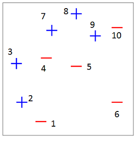

Figura 7.1: Datos originales

En la siguiente figura se muestran 3 clasificadores ($h_{1}$, $h_{2}$, $h_{3}$) sencillos o árboles de profundidad uno, que fueron creados de forma secuencial. Al observar $h_{1}$, se nota que él clasificó mal los $+$ encerrados en círculos. Por esa razón, en la siguiente iteración esas observaciones mal clasificadas tuvieron un mayor peso o importancia en el nuevo clasificador $h_{2}$, por eso es que esos símbolos $+$ aparecen más grandes en la segunda figura.

Al mirar el clasificador $h_{2}$ se ve que logró clasificar bien esos $+$ grandes, sin embargo, él clasificó mal los $-$ que están encerrados en círculos. Por esa razón, en la siguiente iteración esas observaciones mal clasificadas tuvieron un mayor peso o importancia en el nuevo clasificador $h_{3}$, por eso es que esos símbolos $-$ aparecen más grandes en la tercera figura.

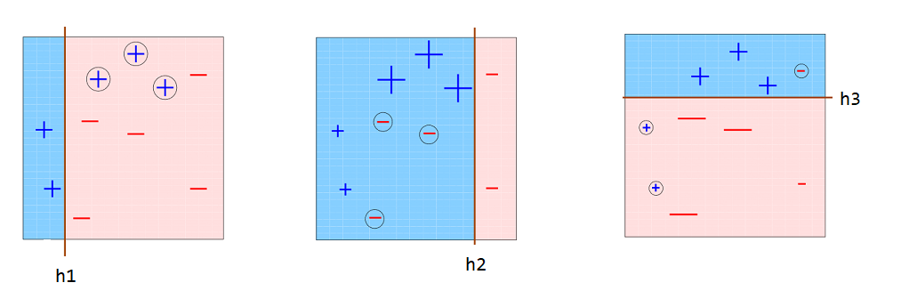

Figura 2: Clasificadores

El clasificador $h_{3}$ logra clasificar mejor esos $-$.

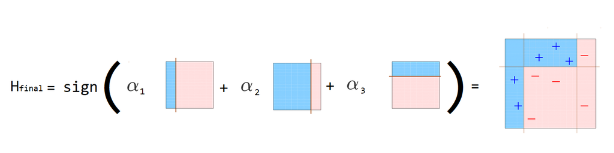

Figura 3: Clasificador final

Vamos a realizar un modelo de boosting con `tidymodels`. Primero, importamos la librería:

```r
library(tidymodels)
```

Hacemos la partición de datos y preprocesamiento del workflow:

```r
set.seed(123)

split <- initial_split(data)
train <- training(split)
test <- testing(split)

recipe <- recipe(realiza_domest ~ ., data = train)%>%
  update_role(ID, new_role = "id") %>%
  step_other(BHCH04_SEL, threshold = 0.2)

wf <- workflow() %>%
  add_recipe(recipe)
```

Ahora, viene la parte de especificar la información del modelo. Como estamos trabajando con boosting, empezamos pasando el parámetro `boost_tree()`. Para elegir entre los tipos de modelos de boosting posibles, hay que modificar el parámetro de `set_engine()`. Por default, tidymodels usa el parámetro `xgboost`para modelos de boosting. Lo vamos a cambiar por C5.0, que sigue un procedimiento similar a AdaBoosting: el modelo final es un ensamble de árboles que hacen un voto ponderado para asignar a la clase final.

```r
bt_spec <- boost_tree(
                    trees = tune(),
                    min_n = tune ()
                    ) %>%
  set_engine("C5.0") %>%
  set_mode("classification")

bt_spec %>% translate()
```

```
## Boosted Tree Model Specification (classification)
##
## Main Arguments:
##   trees = tune()
##   min_n = tune()
##
## Computational engine: C5.0
##
## Model fit template:
## parsnip::C5.0_train(x = missing_arg(), y = missing_arg(), weights = missing_arg(),
##     trials = tune(), minCases = tune())
```

```r
tune_wf <- wf %>%
  add_model(bt_spec)

set.seed(912)

folds <- vfold_cv(train)

tictoc::tic()
tune_params <- tune_wf %>%
   tune_grid(folds,
             metrics = metric_set(precision, recall,
                               roc_auc, f_meas),
             grid = 15)
tictoc::toc()
```

```
## 63.083 sec elapsed
```

Ahora, seleccionamos el mejor modelo en base a `roc_auc` y lo finalizamos.

```r
best_model <- select_best(tune_params, metric = "roc_auc")
final_model <- finalize_model(bt_spec, best_model)
```

Para finalizar, actualizamos el modelo tuneado en el workflow y lo fiteamos.

```r
tree_boost <- wf %>%
   update_model(final_model)
fit_tree <- tree_boost %>% fit(train)

fit_tree
```

```
## ══ Workflow [trained] ══════════════════════════════════════════════════════════
## Preprocessor: Recipe
## Model: boost_tree()
##
## ── Preprocessor ────────────────────────────────────────────────────────────────
## 1 Recipe Step
##
## • step_other()
##
## ── Model ───────────────────────────────────────────────────────────────────────
##
## Call:
## C5.0.default(x = x, y = y, trials = 92L, control = C50::C5.0Control(minCases
##  = 18L, sample = 0))
##
## Classification Tree
## Number of samples: 10762
## Number of predictors: 8
##
## Number of boosting iterations: 92 requested;  23 used due to early stopping
## Average tree size: 7.2
##
## Non-standard options: attempt to group attributes, minimum number of cases: 18
```

Ahora, vamos a predecir sobre el test set, obtener las métricas de evaluación y compararlas con los otros modelos. Recordemos los modelos previos.

```r
cart_final_fit <- read_rds('./models/cart_final_train.rds')
cart_test <- cart_final_fit %>%
  predict(test) %>%
  bind_cols(test, .)
cart_test <- predict(cart_final_fit, test, type = "prob") %>%
  bind_cols(cart_test, .)
```

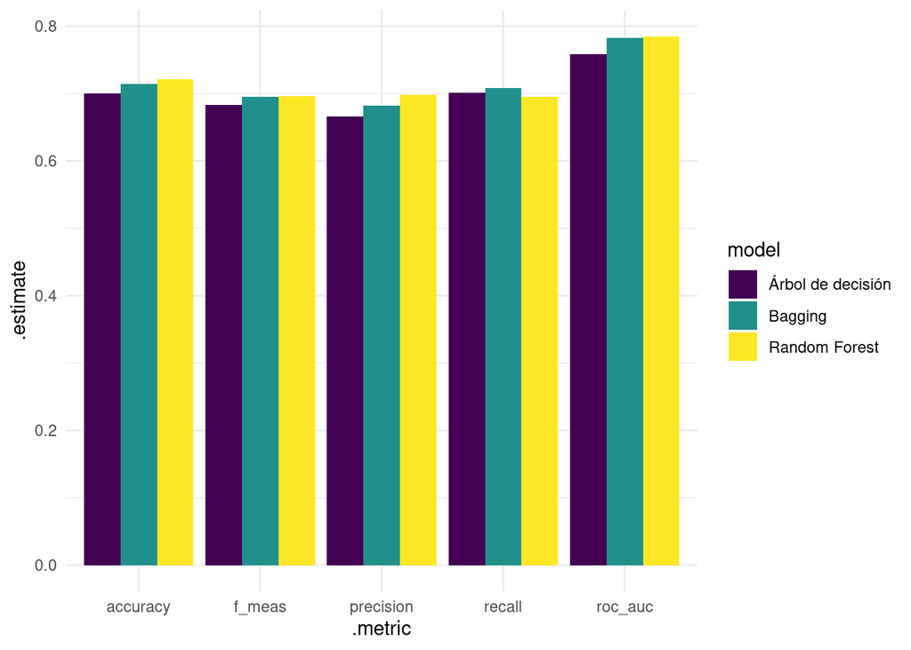

```r
bagging_final_fit <- read_rds('./models/bagging_final_train.rds')
bagging_test <- bagging_final_fit %>%
  predict(test) %>%
  bind_cols(test, .)

bagging_test <- predict(bagging_final_fit, test, type = "prob") %>%
  bind_cols(bagging_test, .)

rf_final_fit <- read_rds('./models/rf_final_train.rds')
rf_test <- rf_final_fit %>%
  predict(test) %>%
  bind_cols(test, .)

rf_test <- predict(rf_final_fit, test, type = "prob") %>%
  bind_cols(rf_test, .)

datasets <- list(cart_test, bagging_test, rf_test)

class_metrics <- metric_set(precision, recall,
                       accuracy, f_meas)

#Hago una función para mapear y no repetir lo mismo 3 veces

metricas <- function(dataset, model_name){

  metrics <-  roc_auc(dataset, truth = realiza_domest, ".pred_No realiza") %>%
    bind_rows(class_metrics(dataset, truth = realiza_domest, estimate = .pred_class))

  return(metrics)
}



metrics_eval <- datasets %>%
  map_dfr(metricas, .id = "model")

metrics_eval <- metrics_eval %>%
  mutate_at(vars(model),
            ~as.factor(
              case_when(
              . %in% "1" ~ "Árbol de decisión",
              . %in% "2" ~ "Bagging",
              . %in% "3" ~ "Random Forest")
            ))

ggplot(metrics_eval, aes(x = .metric, y = .estimate, fill = model))+
  geom_col(position = "dodge")+
  scale_fill_viridis_d()+
  theme_minimal()
```

- ¿Qué modelo funciona mejor? ¿Por qué?

Comparemos, ahora, con Boosting…

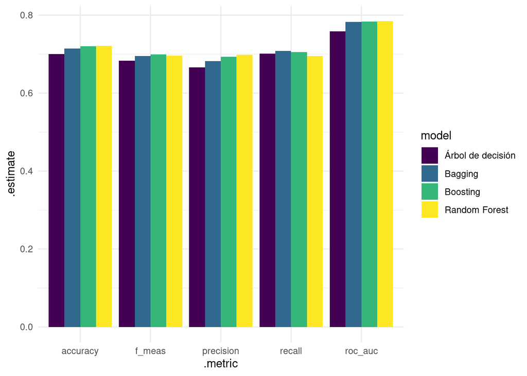

```r
boost_test <- fit_tree %>%
  predict(test) %>%
  bind_cols(., test)

boost_test <- predict(fit_tree, test, type = "prob") %>%
  bind_cols(boost_test, .)

class_metrics <- metric_set(precision, recall,
                       accuracy, f_meas)

boost_metrics <- roc_auc(boost_test, truth = realiza_domest, ".pred_No realiza") %>%
  bind_rows(class_metrics(boost_test, truth = realiza_domest, estimate = .pred_class)) %>%
  mutate(model = "Boosting")

metrics_eval <- bind_rows(metrics_eval, boost_metrics)

ggplot(metrics_eval, aes(x = .metric, y = .estimate, fill = model))+
  geom_col(position = "dodge")+
  scale_fill_viridis_d()+
  theme_minimal()
```

Teniendo en cuenta qué significa cada métrica de evaluación, ¿qué pueden decir de los 4 modelos que probaron?

- ¿Cuál captura mayor cantidad de casos positivos?
- ¿Cuál captura con mayor exactitud los casos positivos?
- ¿Cuál funciona mejor en base a esos dos criterios? ¿Y peor?